# Logistic Regression

## Logistic Regression

- Mount your Drive

```python
from google.colab import drive
drive.mount('/content/drive')
```

- Import Libraries

```python
# you can add more libraries if you want. If confused whether you can use a paticular library consult one of the TAs
import numpy as np
import sklearn
import glob
import cv2
import skimage
import matplotlib.pyplot as plt
from sklearn.model_selection import train_test_split
from sklearn.linear_model import LogisticRegression
from sklearn.metrics import accuracy_score
from sklearn.metrics import f1_score
from sklearn.metrics import precision_score
from sklearn.metrics import confusion_matrix, classification_report, ConfusionMatrixDisplay
from skimage.feature import blob_log
from skimage.measure import regionprops
from numpy.linalg import norm
```

**Part 1: Load Dataset**</br> Create a shortcut of the provided link:</br> [Image Dataset](https://drive.google.com/drive/folders/1R6xFvGyTd3hfG5HaQE1Rs_L4Cw83v_vO?usp=sharing) </br>

Folder Structure </br> forest_fire </br>

> -> Training and Validation </br>

> > --> fire </br> --> nofire </br>

Perform a train-test split on your dataset. </br> Generate labels for the images as well according to their folder names.

```python
# load your dataset here

dataset_path_fire = glob.glob('/content/drive/MyDrive/forest_fire/Training and Validation/fire/*')
dataset_path_nofire = glob.glob('/content/drive/MyDrive/forest_fire/Training and Validation/nofire/*')

Y = [] #labels
X = [] #features

for imgpath in dataset_path_fire:
  img = cv2.resize(cv2.imread(imgpath,cv2.IMREAD_GRAYSCALE), (150, 200), cv2.INTER_AREA)
  feature = np.reshape(img, (img.shape[0]*img.shape[1]))
  X.append(feature )
  Y.append(1)

for imgpath in dataset_path_nofire:
  img = cv2.resize(cv2.imread(imgpath,cv2.IMREAD_GRAYSCALE), (150, 200), cv2.INTER_AREA)
  feature = np.reshape(img, (img.shape[0]*img.shape[1]))
  X.append(feature)
  Y.append(0)
```

```python
def preprocessing(img):
  # takes image array as paramter and preprocesses it
  # feel free to change input and output according to your implementation.


  # X = np.array(X).reshape(len(X), -1)
  # Y = np.array(Y)

  # i, (im1) = plt.subplots(1)
  # i.set_figwidth(15)
  # im1.imshow(X[20])

  # gray_image = skimage.color.rgb2gray(imgdata[200])
  # plt.imshow(gray_image, cmap = 'gray')

  # norm_image = (gray_image - np.min(gray_image)) / (np.max(gray_image) - np.min(gray_image))
  # plt.imshow(norm_image)

  # fireimages[20].flatten()
  pass
```

```python
# train-test split
X_train, X_test, y_train, y_test = train_test_split(X, Y, test_size=0.33, random_state=42)
len(X_train),len(X_test),len(y_train),len(y_test)
```

```
(804, 396, 804, 396)
```

**Part 2: Implementation of Logistic Regression From Scratch (30 Marks)**

You are required to implement **Binary Logistic Regression Model** from scratch keeping in view all the discussions from the class lectures.</br>

- Sigmoid Function </br>

The sigmoid function is used on the classifier to compute the probability of the feature vector x belonging to that class. Then the label of the classifier which returns the highest probability is assigned to x. </br> **If Scikit-Learn is used in this part, you will NOT get any credit.** </br> It is HIGHLY recommended that you use matrix multiplication in your implementation instead of for loops to avoid unnecessary runtime.

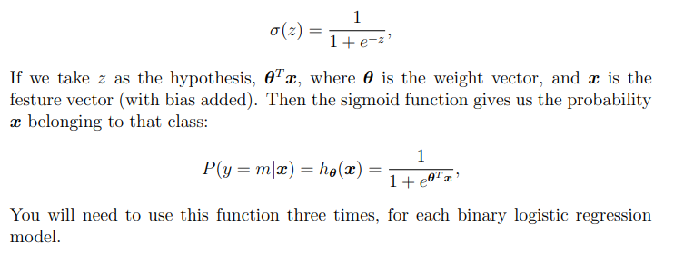

```python
# Implement sigmoid function here
def sigmoid_mapping(z):
  return 1 / (1 + np.exp(-z))
#return 1 / (1 +   np.clip(np.exp(-z), a_min = 0.001, a_max = 1- 0.001) )
```

```python
#HYPOTHESIS FUNCTION
def hypothesis(X, theta):
  return np.dot(X, theta)
```

- Cross Entropy Loss </br>

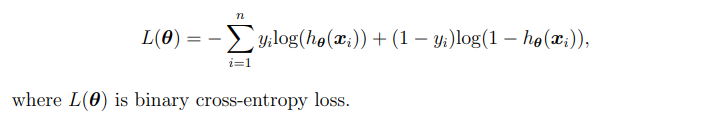

```python
# Implement Cross Entropy Loss here
def Loss_func(X, actual, reg_para, theta):
  z = hypothesis(X,theta)
  loss = - ( (actual.T.dot(np.clip(np.log(sigmoid_mapping(z)), a_min = 0.0000000000001, a_max = 1- 0.0000000000001))) + ( (1-actual).T.dot(np.clip(np.log(1-sigmoid_mapping(z)), a_min = 0.0000000000001, a_max = 1- 0.0000000000001)) ) )
  return loss + reg_para * norm(theta)
```

- Batch Gradient Descent </br>

You will compute the derivative of the new loss expression and update the weights of the model using the derivative during the implementation of batch gradient descent. </br>

Run your batch gradient descent function for large number of epochs, e.g. around 1000, to get good F1-scores.

```python
def batches ( X, actual, batch_size ):
  pass
```

```python
# Implement Batch Gradient Descent here
def Batch_Gradient_Descent(actual, X, alpha, reg_para, epochs, theta, batch_size):
  Losses = np.zeros(epochs,)

  for i in range(epochs):
      theta = theta - (alpha * (np.dot(X.T, (sigmoid_mapping(hypothesis(X,theta)) - actual))))
      #theta = theta - alpha * dot(X.T, self.sigmoid(dot(X,params)) - np.reshape(y,(len(y),1)))
      Losses[i] = Loss_func(X, actual, reg_para, theta)
  return Losses, theta
```

- Prediction Function </br>

It predicts the labels of test data.

```python
# Implement Prediction Function here
def predict (X_test, updated_theta):
  z = hypothesis(X_test,updated_theta)
  pred = []
  for i in sigmoid_mapping(z): # needs to be fixed
            if i>0.5:
                pred.append(1)
            else:
                pred.append(0)

  return np.array(pred)
```

Implementation: </br> Using the above functions, implement your Logistic Regression Classifier. </br> Remember to store the training loss for result visualization. </br>

```python
import warnings

np.seterr(divide = 'ignore')
warnings.filterwarnings('ignore')
```

```python
# add your implementation here

theta = np.zeros(np.array(X_train).shape[1])

#print( len(X), len(Y), len(X_test), len(X_train),  len(y_test), len(y_train),theta )
loss1, y_pred  = Batch_Gradient_Descent(np.array(y_train), np.array(X_train), 0.001, 0.4, 1000, theta, 0)
loss2, y_pred  = Batch_Gradient_Descent(np.array(y_train), np.array(X_train), 0.0001, 0.5, 1000, theta, 0)
loss3, y_pred  = Batch_Gradient_Descent(np.array(y_train), np.array(X_train), 0.00001, 0.6, 1000, theta, 0)

print(predict(X_test,y_pred))
```

```
[0 1 1 0 1 0 1 1 0 0 0 0 1 0 1 1 0 1 0 1 0 1 1 1 1 1 0 1 1 1 1 0 0 1 1 0 1
 1 1 1 0 1 0 0 0 0 0 0 1 0 1 0 0 1 0 1 1 0 0 1 0 0 1 1 1 0 1 0 0 0 1 1 0 1
 1 1 1 1 0 1 0 1 0 1 1 1 0 1 0 1 0 1 1 1 0 1 1 1 0 1 1 1 1 0 1 1 0 0 0 0 1
 0 1 1 1 0 1 1 1 1 1 1 0 0 0 0 1 1 0 1 0 0 0 1 0 1 0 0 0 0 0 0 1 0 0 1 1 1
 1 0 1 1 1 1 1 1 0 0 1 1 0 1 0 0 1 1 1 1 1 1 0 1 1 0 0 1 1 0 1 0 0 1 1 0 0
 0 1 0 0 1 1 1 1 0 0 1 1 1 1 1 1 1 1 1 0 1 0 0 0 1 0 0 0 0 0 0 1 1 0 0 0 0
 1 0 0 0 1 0 1 0 0 1 0 1 0 1 0 0 0 1 1 1 0 0 1 0 1 1 1 1 1 0 1 0 0 1 1 1 1
 0 0 1 1 0 1 0 0 0 0 1 0 0 0 0 1 1 1 1 0 1 0 1 1 1 0 1 0 1 0 0 1 0 1 1 1 0
 1 1 1 1 1 0 1 0 0 1 0 1 0 1 1 1 0 1 1 0 1 0 1 0 0 1 0 0 1 0 1 0 1 0 0 0 0
 1 0 0 0 1 0 0 0 0 0 1 1 0 0 0 0 1 1 1 1 1 1 1 0 1 1 1 1 0 1 1 1 1 1 0 0 0
 0 1 1 0 1 1 0 0 1 0 1 0 0 0 1 0 0 1 1 1 1 0 1 1 1 0]
```

Visualize Results on Training Data: </br>

Plot graphs for different values of learning rate and regularization parameter with no of epochs on the x-axis and training loss on the y-axis. </br> The overall loss is computed by adding the loss of all classifiers. </br>

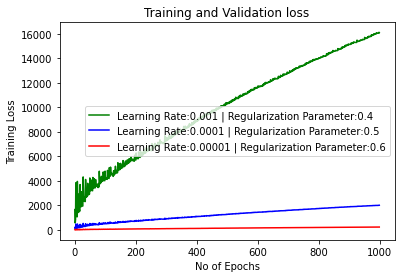

```python
# Plot results for training loss here
epochs = range(0,1000)
plt.plot(epochs, loss1, 'g', label='Learning Rate:0.001 | Regularization Parameter:0.4')
plt.plot(epochs, loss2, 'b', label='Learning Rate:0.0001 | Regularization Parameter:0.5')
plt.plot(epochs, loss3, 'r', label='Learning Rate:0.00001 | Regularization Parameter:0.6')

plt.title('Training and Validation loss')
plt.xlabel('No of Epochs')
plt.ylabel('Training Loss')
plt.legend()
plt.show()
```

- Evaluation function </br>

It calculates classification accuracy, F1 score and confusion matrix. Pass the labels of test data in this function and report your results.

```python
# Implement Evaluation Function here
def Evaluation(labels, predicted):
    # Calculate confusion matrix
    confusion = np.zeros((2, 2))
    for i in range(len(labels)):
        confusion[labels[i], predicted[i]] += 1

    # Calculate classification accuracy
    accuracy = np.sum(np.diag(confusion)) / np.sum(confusion)

    # Calculate precision, recall, and F1 score for each class
    precision = np.zeros(2)
    recall = np.zeros(2)
    f1_score = np.zeros(2)
    for i in range(2):
        tp = confusion[i, i]
        fp = np.sum(confusion[:, i]) - tp
        fn = np.sum(confusion[i, :]) - tp
        precision[i] = tp / (tp + fp)
        recall[i] = tp / (tp + fn)
        f1_score[i] = 2 * precision[i] * recall[i] / (precision[i] + recall[i])

    return confusion, accuracy, f1_score
```

```python
# Call Evaluation Function here
confusion, accuracy, f1_score = Evaluation(y_test, predict(X_test,y_pred))

print(confusion)
print(accuracy)
print(f1_score)
```

```
[[160. 139.]
 [ 23.  74.]]
0.5909090909090909
[0.66390041 0.47741935]
```

**Part-3: Logistic Regression using Scikit-Learn (10 Marks)**

```python
# Implement Logistic Regression using Scikit-Learn library here
from sklearn.model_selection import train_test_split
from sklearn.linear_model import LogisticRegression

x_train, x_test, y_train, y_test = train_test_split(X, Y, test_size=0.33)

logisticRegr = LogisticRegression()

logisticRegr.fit(x_train, y_train)

# Returns a NumPy Array
# Predict for One Observation (image)
logisticRegr.predict(x_test[0].reshape(1,-1))

predictions = logisticRegr.predict(x_test)
```

```python
# Call Evaluation Function here
# Use score method to get accuracy of model
score = logisticRegr.score(x_test, y_test)
print(score)
```

```
0.7045454545454546
```